# LeafCutter Pipeline Audit Report

NMD Differential Splicing: Smg1i vs. DMSO, donor-adjusted

Sanika Thakur

November 18, 2026

# Pipeline Parameters

```r
data.frame(
  Stage = c("regtools", "regtools", "regtools", "regtools",
            "Clustering", "Clustering",
            "DS", "DS", "DS", "DS", "DS"),
  Parameter = c("-a (anchor)", "-m (min intron)", "-M (max intron)", "-s (strand)",
                "-m (min reads)", "-l (max intron)",
                "Model", "Covariate", "-i (min samples per intron)",
                "-g (min samples per group)", "-c (min coverage)"),
  Value = c("6", "10", "1,000,000", "RF",
            "10", "1,000,000",
            "Dirichlet-multinomial GLM", "donor", "3", "3", "20"),
  Description = c("Min bases on each side of junction", "Min intron length",
                  "Max intron length", "fr-firststrand library",
                  "Min reads supporting a cluster", "Max intron length",
                  "Smg1i vs DMSO", "Paired design: each donor has a DMSO and a Smg1i sample",
                  "Intron must be seen in at least 3 samples",
                  "At least 3 samples per group must pass coverage",
                  "Min reads per cluster in a sample")
) %>%
  kable() %>%
  kable_styling(bootstrap_options = c("striped", "hover", "condensed"), full_width = FALSE) %>%
  collapse_rows(columns = 1, valign = "top")
```

| Stage | Parameter | Value | Description |
| --- | --- | --- | --- |
| regtools | -a (anchor) | 6 | Min bases on each side of junction |
|  | -m (min intron) | 10 | Min intron length |
|  | -M (max intron) | 1,000,000 | Max intron length |
|  | -s (strand) | RF | fr-firststrand library |
| Clustering | -m (min reads) | 10 | Min reads supporting a cluster |
|  | -l (max intron) | 1,000,000 | Max intron length |
| DS | Model | Dirichlet-multinomial GLM | Smg1i vs DMSO |
|  | Covariate | donor | Paired design: each donor has a DMSO and a Smg1i sample |
|  | -i (min samples per intron) | 3 | Intron must be seen in at least 3 samples |
|  | -g (min samples per group) | 3 | At least 3 samples per group must pass coverage |
|  | -c (min coverage) | 20 | Min reads per cluster in a sample |

**Internal hardcoded filters** in `leafcutter_cluster_regtools.py`:

- Junction must have ≥3 reads in at least one sample
- Singleton clusters (1 intron) are removed
- `refine_cluster` recursively splits clusters based on min ratio

**Annotation**: Gencode v45 primary assembly **Reads**: Paired-end, 150bp, fr-firststrand

# Overview

This report follows the data through the LeafCutter differential splicing pipeline for four cell types (**AT2, DD, FB, MV**), comparing **Smg1i** (NMD inhibition) with **DMSO** (control). Compared with the earlier run, the differential splicing model now includes **donor** as a covariate, because every donor contributes one DMSO and one Smg1i sample.

**Pipeline stages:**

1. **BAM → Junctions**: `regtools junctions extract` writes one `.junc` file per sample
2. **Junctions → Clustering**: `leafcutter_cluster_regtools.py` groups junctions into intron clusters
3. **Clustering → Differential Splicing**: `leafcutter_ds.R` tests for differential intron usage, with `~ treatment + donor`

**Sign convention.** LeafCutter uses the first group in `samples.tsv` as the reference. Here that is Smg1i, so the raw `deltapsi` column is DMSO − Smg1i. Every ΔPSI shown in this report is recomputed as **Smg1i − DMSO**, so a positive value means the intron is used more when NMD is blocked.

# Sample Design

```r
samples_df <- rbindlist(lapply(cell_types, read_samples))

samples_df %>%
  select(cell_type, sample, condition, donor) %>%
  arrange(cell_type, donor, condition) %>%
  kable(col.names = c("Cell Type", "Sample", "Condition", "Donor"),
        caption = "Samples and donors used in each cell type") %>%
  kable_styling(bootstrap_options = c("striped", "hover", "condensed"), full_width = FALSE) %>%
  collapse_rows(columns = 1, valign = "top")
```

Samples and donors used in each cell type

| Cell Type | Sample | Condition | Donor |
| --- | --- | --- | --- |
| AT2 | AT2001V_DMSO.markdup.sorted | DMSO | 001V |
|  | AT2001V_Smg1i.markdup.sorted | Smg1i | 001V |
|  | AT2027U_DMSO.markdup.sorted | DMSO | 027U |
|  | AT2027U_Smg1i.markdup.sorted | Smg1i | 027U |
|  | AT2029T_DMSO.markdup.sorted | DMSO | 029T |
|  | AT2029T_Smg1i.markdup.sorted | Smg1i | 029T |
| DD | DD010R_DMSO.markdup.sorted | DMSO | 010R |
|  | DD010R_Smg1i.markdup.sorted | Smg1i | 010R |
|  | DD017Q_DMSO.markdup.sorted | DMSO | 017Q |
|  | DD017Q_Smg1i.markdup.sorted | Smg1i | 017Q |
|  | DD047N_DMSO.markdup.sorted | DMSO | 047N |
|  | DD047N_Smg1i.markdup.sorted | Smg1i | 047N |
|  | DD066Q_DMSO.markdup.sorted | DMSO | 066Q |
|  | DD066Q_Smg1i.markdup.sorted | Smg1i | 066Q |
| FB | FB001V_DMSO.markdup.sorted | DMSO | 001V |
|  | FB001V_Smg1i.markdup.sorted | Smg1i | 001V |
|  | FB027U_DMSO.markdup.sorted | DMSO | 027U |
|  | FB027U_Smg1i.markdup.sorted | Smg1i | 027U |
|  | FB029T_DMSO_clean.markdup.sorted | DMSO | 029T |
|  | FB029T_Smg1i_clean.markdup.sorted | Smg1i | 029T |
| MV | MV001V_DMSO.markdup.sorted | DMSO | 001V |
|  | MV001V_Smg1i.markdup.sorted | Smg1i | 001V |
|  | MV027U_DMSO.markdup.sorted | DMSO | 027U |
|  | MV027U_Smg1i.markdup.sorted | Smg1i | 027U |
|  | MV029T_DMSO.markdup.sorted | DMSO | 029T |
|  | MV029T_Smg1i.markdup.sorted | Smg1i | 029T |

# Stage 1: BAM → Junction Extraction (regtools)

```r
junc_df  <- list()
track_df <- list()
clust_df <- list()

for (ct in cell_types) {
  # counts file (clustering output) for this cell type
  cnt <- read_count_ids(ct)
  parts <- tstrsplit(cnt$ids, ":", fixed = TRUE)
  count_coords <- unique(paste(parts[[1]], parts[[2]], parts[[3]], sep = ":"))
  clusters <- paste(parts[[1]], parts[[4]], sep = ":")
  per_cluster <- table(clusters)

  clust_df[[ct]] <- data.frame(
    cell_type = ct, n_samples = cnt$n_samples, n_introns = length(cnt$ids),
    n_clusters = length(per_cluster),
    introns_per_cluster_median = median(as.integer(per_cluster)),
    introns_per_cluster_max = max(per_cluster))

  # per-sample junction files
  smp <- read_samples(ct)
  pooled <- list()
  for (f in junc_paths(ct)) {
    nm <- sub("\\.junc$", "", basename(f))
    j <- read_junc(f)
    pooled[[nm]] <- j
    junc_df[[paste(ct, nm)]] <- data.frame(
      cell_type = ct, sample = nm,
      condition = smp$condition[match(nm, smp$sample)],
      donor = smp$donor[match(nm, smp$sample)],
      n_junctions = nrow(j))
  }
  pooled_u <- unique(rbindlist(pooled))
  rm(pooled)

  # LeafCutter may shift intron ends by one base; use whichever offset matches its coordinates
  offsets <- expand.grid(ds = 0:1, de = 0:1)
  rates <- apply(offsets, 1, function(o)
    mean(count_coords %in% paste(pooled_u$chr, pooled_u$i_start + o[1],
                                 pooled_u$i_end + o[2], sep = ":")))
  best <- offsets[which.max(rates), ]
  junc_coords <- unique(paste(pooled_u$chr, pooled_u$i_start + best$ds,
                              pooled_u$i_end + best$de, sep = ":"))

  track_df[[ct]] <- data.frame(
    cell_type = ct,
    total_junctions_all_samples = sum(sapply(junc_df[startsWith(names(junc_df), paste0(ct, " "))],
                                             `[[`, "n_junctions")),
    unique_junctions_input = length(junc_coords),
    unique_introns_after = length(cnt$ids),
    clusters_formed = length(per_cluster),
    introns_used_in_clusters = length(count_coords),
    introns_excluded = length(junc_coords) - length(count_coords),
    pct_clustered_found_in_junc = round(100 * max(rates), 2))
}

junc_df  <- bind_rows(junc_df)
track_df <- bind_rows(track_df)
clust_df <- bind_rows(clust_df)
```

## Per-Sample Junction Counts

```r
junc_df %>%
  arrange(cell_type, donor, condition) %>%
  mutate(n_junctions = comma(n_junctions)) %>%
  select(cell_type, sample, condition, donor, n_junctions) %>%
  kable(col.names = c("Cell Type", "Sample", "Condition", "Donor", "Junctions"),
        caption = "Junctions per sample from regtools") %>%
  kable_styling(bootstrap_options = c("striped", "hover", "condensed"), full_width = FALSE) %>%
  collapse_rows(columns = 1, valign = "top")
```

Junctions per sample from regtools

| Cell Type | Sample | Condition | Donor | Junctions |
| --- | --- | --- | --- | --- |
| AT2 | AT2001V_DMSO.markdup.sorted | DMSO | 001V | 391,321 |
|  | AT2001V_Smg1i.markdup.sorted | Smg1i | 001V | 417,154 |
|  | AT2027U_DMSO.markdup.sorted | DMSO | 027U | 432,712 |
|  | AT2027U_Smg1i.markdup.sorted | Smg1i | 027U | 541,354 |
|  | AT2029T_DMSO.markdup.sorted | DMSO | 029T | 409,098 |
|  | AT2029T_Smg1i.markdup.sorted | Smg1i | 029T | 507,145 |
| DD | DD010R_DMSO.markdup.sorted | DMSO | 010R | 462,945 |
|  | DD010R_Smg1i.markdup.sorted | Smg1i | 010R | 631,290 |
|  | DD017Q_DMSO.markdup.sorted | DMSO | 017Q | 473,297 |
|  | DD017Q_Smg1i.markdup.sorted | Smg1i | 017Q | 674,143 |
|  | DD047N_DMSO.markdup.sorted | DMSO | 047N | 505,537 |
|  | DD047N_Smg1i.markdup.sorted | Smg1i | 047N | 616,773 |
|  | DD066Q_DMSO.markdup.sorted | DMSO | 066Q | 453,378 |
|  | DD066Q_Smg1i.markdup.sorted | Smg1i | 066Q | 658,217 |
| FB | FB001V_DMSO.markdup.sorted | DMSO | 001V | 342,583 |
|  | FB001V_Smg1i.markdup.sorted | Smg1i | 001V | 441,765 |
|  | FB027U_DMSO.markdup.sorted | DMSO | 027U | 348,662 |
|  | FB027U_Smg1i.markdup.sorted | Smg1i | 027U | 391,543 |
|  | FB029T_DMSO_clean.markdup.sorted | DMSO | 029T | 320,627 |
|  | FB029T_Smg1i_clean.markdup.sorted | Smg1i | 029T | 504,194 |
| MV | MV001V_DMSO.markdup.sorted | DMSO | 001V | 254,010 |
|  | MV001V_Smg1i.markdup.sorted | Smg1i | 001V | 405,532 |
|  | MV027U_DMSO.markdup.sorted | DMSO | 027U | 298,510 |
|  | MV027U_Smg1i.markdup.sorted | Smg1i | 027U | 360,587 |
|  | MV029T_DMSO.markdup.sorted | DMSO | 029T | 338,658 |
|  | MV029T_Smg1i.markdup.sorted | Smg1i | 029T | 384,243 |

## Summary by Cell Type

```r
junc_df %>%
  group_by(cell_type) %>%
  summarise(n_samples = n(), total = sum(n_junctions),
            mean = mean(n_junctions), min = min(n_junctions), max = max(n_junctions),
            .groups = "drop") %>%
  mutate(across(total:max, comma)) %>%
  kable(caption = "Junction count summary per cell type") %>%
  kable_styling(bootstrap_options = c("striped", "hover"), full_width = FALSE)
```

Junction count summary per cell type

| cell_type | n_samples | total | mean | min | max |
| --- | --- | --- | --- | --- | --- |
| AT2 | 6 | 2,698,784 | 449,797 | 391,321 | 541,354 |
| DD | 8 | 4,475,580 | 559,448 | 453,378 | 674,143 |
| FB | 6 | 2,349,374 | 391,562 | 320,627 | 504,194 |
| MV | 6 | 2,041,540 | 340,257 | 254,010 | 405,532 |

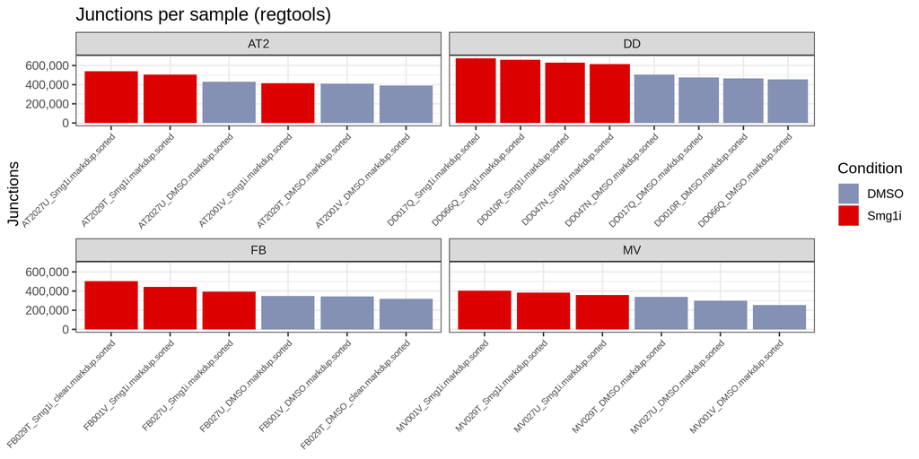

```r
ggplot(junc_df, aes(x = reorder(sample, -n_junctions), y = n_junctions, fill = condition)) +
  geom_col() +
  facet_wrap(~cell_type, scales = "free_x") +
  scale_fill_manual(values = cond_colors) +
  scale_y_continuous(labels = comma) +
  labs(title = "Junctions per sample (regtools)", x = NULL, y = "Junctions", fill = "Condition") +
  theme(axis.text.x = element_text(angle = 45, hjust = 1, size = 7))
```

## Paired Comparison: Smg1i vs DMSO Within Donor

Each line joins the two samples from one donor. Smg1i samples usually have more junctions, because transcripts that NMD would normally degrade survive and add new splice junctions.

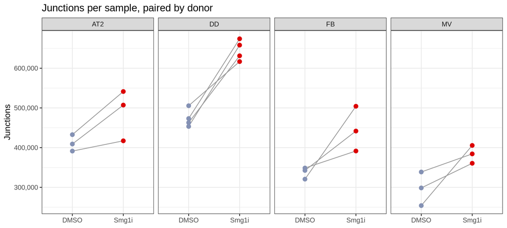

```r
junc_df %>%
  filter(!is.na(donor)) %>%
  mutate(condition = factor(condition, levels = c("DMSO", "Smg1i"))) %>%
  ggplot(aes(x = condition, y = n_junctions, group = donor)) +
  geom_line(colour = "grey60") +
  geom_point(aes(colour = condition), size = 2.5) +
  facet_wrap(~cell_type, nrow = 1) +
  scale_colour_manual(values = cond_colors) +
  scale_y_continuous(labels = comma) +
  labs(title = "Junctions per sample, paired by donor", x = NULL, y = "Junctions") +
  theme(legend.position = "none")
```

# Stage 2: Junction → Clustering (LeafCutter)

## Clustering Summary

```r
clust_df %>%
  mutate(across(c(n_introns, n_clusters), comma)) %>%
  kable(caption = "Post-clustering: introns and clusters per cell type") %>%
  kable_styling(bootstrap_options = c("striped", "hover"), full_width = FALSE)
```

Post-clustering: introns and clusters per cell type

| cell_type | n_samples | n_introns | n_clusters | introns_per_cluster_median | introns_per_cluster_max |
| --- | --- | --- | --- | --- | --- |
| AT2 | 5 | 209,949 | 49,168 | 3 | 180 |
| DD | 7 | 312,641 | 55,136 | 4 | 182 |
| FB | 5 | 216,708 | 48,046 | 3 | 153 |
| MV | 5 | 200,424 | 46,054 | 3 | 203 |

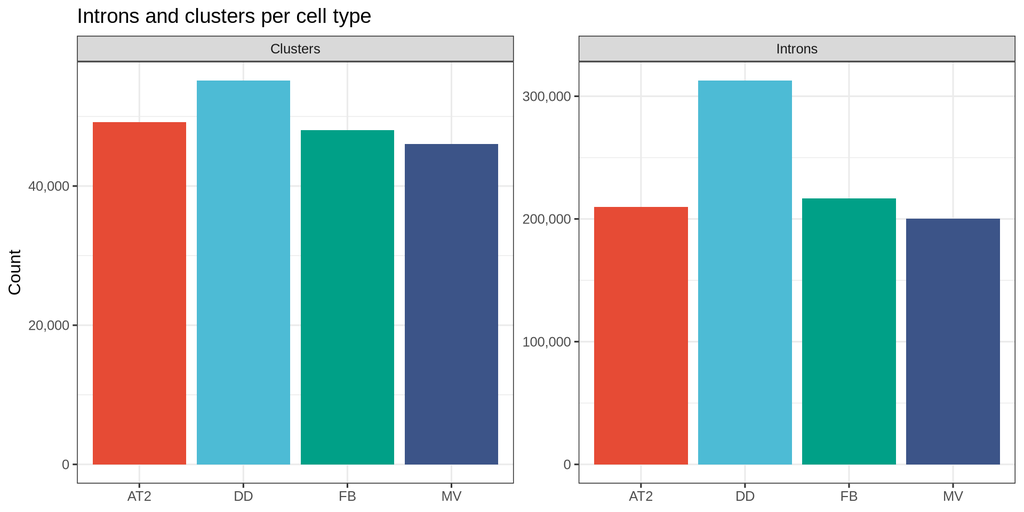

```r
clust_df %>%
  select(cell_type, n_introns, n_clusters) %>%
  pivot_longer(-cell_type, names_to = "metric", values_to = "count") %>%
  mutate(metric = recode(metric, n_introns = "Introns", n_clusters = "Clusters")) %>%
  ggplot(aes(x = cell_type, y = count, fill = cell_type)) +
  geom_col(show.legend = FALSE) +
  facet_wrap(~metric, scales = "free_y") +
  scale_fill_manual(values = ct_colors) +
  scale_y_continuous(labels = comma) +
  labs(title = "Introns and clusters per cell type", x = NULL, y = "Count")
```

# Stage 1 → 2: Junction-to-Cluster Tracking

```r
track_df %>%
  mutate(across(total_junctions_all_samples:introns_excluded, comma)) %>%
  kable(col.names = c("Cell Type", "Total Junc (all samples)", "Unique Junc Input",
                      "Unique Introns After", "Clusters Formed",
                      "Introns Used in Clusters", "Introns Excluded",
                      "% Clustered Introns Found in .junc"),
        caption = "Full junction-to-cluster tracking") %>%
  kable_styling(bootstrap_options = c("striped", "hover"), full_width = FALSE)
```

Full junction-to-cluster tracking

| Cell Type | Total Junc (all samples) | Unique Junc Input | Unique Introns After | Clusters Formed | Introns Used in Clusters | Introns Excluded | % Clustered Introns Found in .junc |
| --- | --- | --- | --- | --- | --- | --- | --- |
| AT2 | 2,698,784 | 847,697 | 209,949 | 49,168 | 208,289 | 639,408 | 100 |
| DD | 4,475,580 | 1,289,654 | 312,641 | 55,136 | 309,783 | 979,871 | 100 |
| FB | 2,349,374 | 808,645 | 216,708 | 48,046 | 214,529 | 594,116 | 100 |
| MV | 2,041,540 | 687,323 | 200,424 | 46,054 | 199,025 | 488,298 | 100 |

### Column Definitions

**Total Junc (all samples):** every junction line across all `.junc` files for the cell type. A junction seen in 6 samples counts 6 times, so this reflects the total splicing evidence across the BAMs.

**Unique Junc Input:** distinct intron coordinates (`chr:start:end`) pooled across samples. This is what goes into LeafCutter clustering. Intron coordinates are taken from the BED12 anchor blocks, so the same intron gets the same coordinates in every sample even when the anchor lengths differ.

**Unique Introns After:** rows in `_perind_numers.counts.gz`. This can be slightly higher than *Introns Used in Clusters*, because one coordinate can appear in two clusters (for example on opposite strands) and each copy is its own row.

**Clusters Formed:** distinct `clu_XXXX` identifiers in the counts file. Each cluster is a group of two or more introns sharing a splice site.

**Introns Used in Clusters:** distinct `chr:start:end` coordinates in at least one cluster, counted once each.

**Introns Excluded:** *Unique Junc Input* minus *Introns Used in Clusters*. These are junctions regtools found but LeafCutter dropped because they had fewer than 3 reads in every sample, did not share a splice site with any other junction, or were removed by `refine_cluster`.

**% Clustered Introns Found in .junc:** a sanity check. Nearly every clustered intron should be traceable to the `.junc` files, so this should be close to 100%.

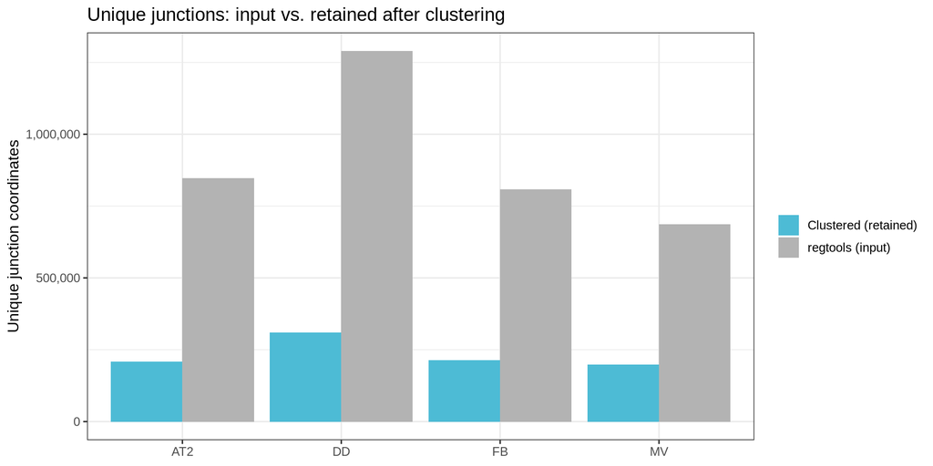

```r
track_df %>%
  select(cell_type, unique_junctions_input, introns_used_in_clusters) %>%
  pivot_longer(-cell_type, names_to = "stage", values_to = "count") %>%
  mutate(stage = recode(stage,
    unique_junctions_input   = "regtools (input)",
    introns_used_in_clusters = "Clustered (retained)")) %>%
  ggplot(aes(x = cell_type, y = count, fill = stage)) +
  geom_col(position = "dodge") +
  scale_fill_manual(values = c("regtools (input)" = "#B3B3B3", "Clustered (retained)" = "#4DBBD5")) +
  scale_y_continuous(labels = comma) +
  labs(title = "Unique junctions: input vs. retained after clustering",
       x = NULL, y = "Unique junction coordinates", fill = NULL)
```

# Stage 3: Clustering → Differential Splicing

```r
load_ds <- function(ct) {
  sig <- fread(ct_file(ct, "_cluster_significance.txt"))
  setnames(sig, "p.adjust", "padj")
  eff <- fread(ct_file(ct, "_effect_sizes.txt"))
  has_groups <- all(c("Smg1i", "DMSO") %in% names(eff))
  if (has_groups) eff[, dpsi := Smg1i - DMSO] else eff[, dpsi := -deltapsi]
  parts <- tstrsplit(eff$intron, ":", fixed = TRUE)
  eff[, cluster := paste(parts[[1]], parts[[4]], sep = ":")]
  top <- eff[eff[, .I[which.max(abs(dpsi))], by = cluster]$V1,
             .(cluster, top_intron = intron, max_dpsi = dpsi)]
  sig <- merge(sig, top, by = "cluster", all.x = TRUE)
  list(sig = sig, eff = eff, has_groups = has_groups)
}

ds <- setNames(lapply(cell_types, load_ds), cell_types)
```

## Sign Check

```r
lapply(cell_types, function(ct) {
  e <- ds[[ct]]$eff
  if (!ds[[ct]]$has_groups) {
    return(data.frame(cell_type = ct, raw_deltapsi = "group columns missing, assumed DMSO − Smg1i",
                      cor_with_DMSO_minus_Smg1i = NA))
  }
  r <- cor(e$deltapsi, e$DMSO - e$Smg1i, use = "complete.obs")
  data.frame(cell_type = ct,
             raw_deltapsi = ifelse(r > 0.99, "DMSO − Smg1i", ifelse(r < -0.99, "Smg1i − DMSO", "unclear")),
             cor_with_DMSO_minus_Smg1i = round(r, 4))
}) %>%
  bind_rows() %>%
  kable(col.names = c("Cell Type", "Raw deltapsi column is", "cor(deltapsi, DMSO − Smg1i)"),
        caption = "Direction of LeafCutter's deltapsi column. All values below use Smg1i − DMSO.") %>%
  kable_styling(bootstrap_options = c("striped", "hover"), full_width = FALSE)
```

Direction of LeafCutter’s deltapsi column. All values below use Smg1i − DMSO.

| Cell Type | Raw deltapsi column is | cor(deltapsi, DMSO − Smg1i) |
| --- | --- | --- |
| AT2 | DMSO − Smg1i | 1 |
| DD | DMSO − Smg1i | 1 |
| FB | DMSO − Smg1i | 1 |
| MV | DMSO − Smg1i | 1 |

## Cluster Status

```r
status_df <- bind_rows(lapply(cell_types, function(ct)
  ds[[ct]]$sig[, .N, by = status][, cell_type := ct]))

status_df %>%
  pivot_wider(names_from = cell_type, values_from = N, values_fill = 0) %>%
  arrange(desc(.data[[cell_types[1]]])) %>%
  kable(caption = "LeafCutter status of every cluster, per cell type") %>%
  kable_styling(bootstrap_options = c("striped", "hover"), full_width = FALSE)
```

LeafCutter status of every cluster, per cell type

| status | AT2 | DD | FB | MV |
| --- | --- | --- | --- | --- |
| Success | 38043 | 45501 | 34696 | 33789 |
| Not enough valid samples | 4543 | 4095 | 4662 | 4224 |
| <2 introns used in >=min_samples_per_intron samples | 3752 | 1405 | 5434 | 5434 |
| <=1 sample with coverage>min_coverage | 2791 | 4110 | 3179 | 2515 |
| <=1 sample with coverage>0 | 39 | 24 | 75 | 92 |
| Error: Initialization failed. | 0 | 1 | 0 | 0 |

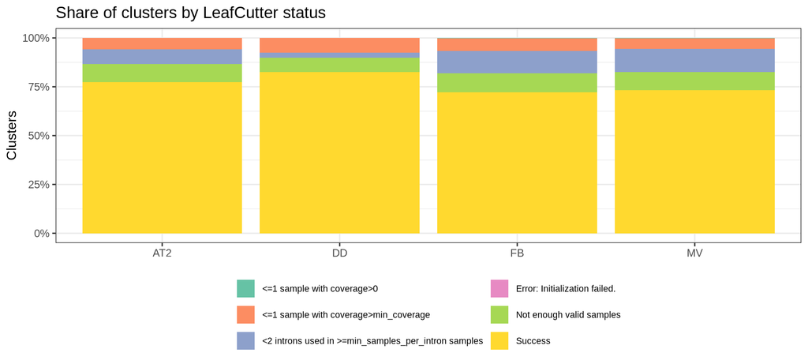

```r
ggplot(status_df, aes(x = cell_type, y = N, fill = status)) +
  geom_col(position = "fill") +
  scale_y_continuous(labels = percent) +
  scale_fill_brewer(palette = "Set2") +
  labs(title = "Share of clusters by LeafCutter status", x = NULL, y = "Clusters", fill = NULL) +
  theme(legend.position = "bottom", legend.text = element_text(size = 8)) +
  guides(fill = guide_legend(ncol = 2))
```

## DS Summary

```r
ds_df <- bind_rows(lapply(cell_types, function(ct) {
  s <- ds[[ct]]$sig
  hits <- s[status == "Success" & padj < params$fdr]
  strong <- hits[abs(max_dpsi) >= params$min_dpsi]
  data.frame(cell_type = ct,
             n_introns = nrow(ds[[ct]]$eff),
             clusters_total = nrow(s),
             clusters_tested = sum(s$status == "Success"),
             sig = nrow(hits),
             sig_strong = nrow(strong),
             up_smg1i = sum(strong$max_dpsi > 0),
             down_smg1i = sum(strong$max_dpsi < 0))
}))

ds_df %>%
  mutate(across(n_introns:down_smg1i, comma)) %>%
  kable(col.names = c("Cell Type", "Introns Tested", "Clusters", "Clusters Tested",
                      paste0("Sig (p.adj < ", params$fdr, ")"),
                      paste0("Sig and |ΔPSI| ≥ ", params$min_dpsi),
                      "Up in Smg1i", "Down in Smg1i"),
        caption = "Differential splicing summary per cell type. Up/Down use the cluster's largest-effect intron.") %>%
  kable_styling(bootstrap_options = c("striped", "hover"), full_width = FALSE) %>%
  add_header_above(c(" " = 6, "Direction (strong hits)" = 2))
```

Differential splicing summary per cell type. Up/Down use the cluster’s largest-effect intron.

| Cell Type | Introns Tested | Clusters | Clusters Tested | Sig (p.adj < 0.05) | Sig and &#124;ΔPSI&#124; ≥ 0.1 | Direction (strong hits) Up in Smg1i | Direction (strong hits) Down in Smg1i |
| --- | --- | --- | --- | --- | --- | --- | --- |
| AT2 | 164,968 | 49,168 | 38,043 | 15,358 | 2,750 | 668 | 2,082 |
| DD | 273,014 | 55,136 | 45,501 | 25,958 | 3,488 | 905 | 2,583 |
| FB | 158,978 | 48,046 | 34,696 | 13,721 | 2,474 | 733 | 1,741 |
| MV | 146,324 | 46,054 | 33,789 | 16,683 | 4,283 | 1,156 | 3,127 |

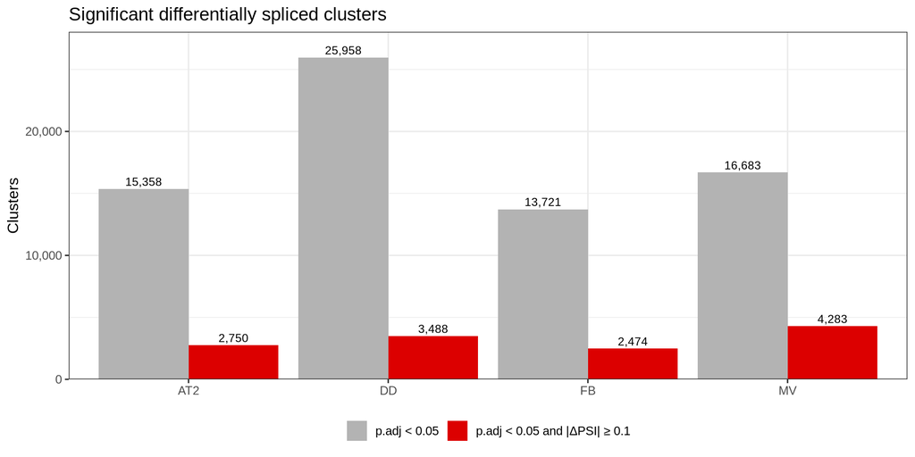

```r
ds_df %>%
  select(cell_type, sig, sig_strong) %>%
  pivot_longer(-cell_type, names_to = "set", values_to = "n") %>%
  mutate(set = recode(set, sig = paste0("p.adj < ", params$fdr),
                      sig_strong = paste0("p.adj < ", params$fdr, " and |ΔPSI| ≥ ", params$min_dpsi))) %>%
  ggplot(aes(x = cell_type, y = n, fill = set)) +
  geom_col(position = "dodge") +
  geom_text(aes(label = comma(n)), position = position_dodge(width = 0.9), vjust = -0.4, size = 3.2) +
  scale_fill_manual(values = c("#B3B3B3", "#DC0000")) +
  scale_y_continuous(labels = comma, expand = expansion(mult = c(0, 0.08))) +
  labs(title = "Significant differentially spliced clusters", x = NULL, y = "Clusters", fill = NULL) +
  theme(legend.position = "bottom")
```

## P-value Distributions

A spike near 0 on a flat background is the expected shape. A bump near 1 or a U shape would suggest a problem with the model or the groups.

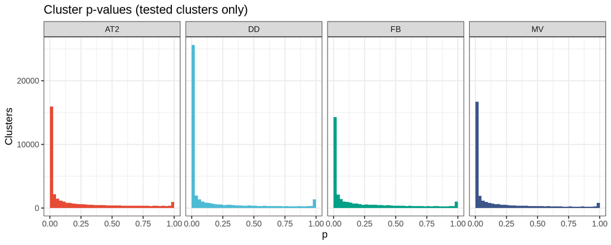

```r
bind_rows(lapply(cell_types, function(ct)
  ds[[ct]]$sig[status == "Success", .(cell_type = ct, p)])) %>%
  ggplot(aes(x = p, fill = cell_type)) +
  geom_histogram(breaks = seq(0, 1, 0.025), show.legend = FALSE) +
  facet_wrap(~cell_type, nrow = 1) +
  scale_fill_manual(values = ct_colors) +
  labs(title = "Cluster p-values (tested clusters only)", x = "p", y = "Clusters")
```